# Final Project Notebook

DS 5001 Text as Data | Spring 2025

# Metadata

- Full Name: Lindley Slipetz
- Userid: ddj6tu
- GitHub Repo URL: https://github.com/sliplr19/Text_Analysis_Final_Project_2025
- UVA Box URL:https://virginia.box.com/s/m6thvsb2xritk7jz3xhayjn24ptidulf

# Overview

The goal of the final project is for you to create a **digital analytical edition** of a corpus using the tools, practices, and perspectives you’ve learning in this course. You will select a corpus that has already been digitized and transcribed, parse that into an F-compliant set of tables, and then generate and visualize the results of a series of fitted models. You will also draw some tentative conclusions regarding the linguistic, cultural, psychological, or historical features represented by your corpus. The point of the exercise is to have you work with a corpus through the entire pipeline from ingestion to interpretation.

Specifically, you will acquire a collection of long-form texts and perform the following operations:

- **Convert** the collection from their source formats (F0) into a set of tables that conform to the Standard Text Analytic Data Model (F2).
- **Annotate** these tables with statistical and linguistic features using NLP libraries such as NLTK (F3).
- **Produce** a vector representation of the corpus to generate TFIDF values to add to the TOKEN (aka CORPUS) and VOCAB tables (F4).
- **Model** the annotated and vectorized model with tables and features derived from the application of unsupervised methods, including PCA, LDA, and word2vec (F5).
- **Explore** your results using statistical and visual methods.
- **Present** conclusions about patterns observed in the corpus by means of these operations.

When you are finished, you will make the results of your work available in GitHub (for code) and UVA Box (for data). You will submit to Gradescope (via Canvas) a PDF version of a Jupyter notebook that contains the information listed below.

# Some Details

- Please fill out your answers in each task below by editing the markdown cell.
- Replace text that asks you to insert something with the thing, i.e. replace `(INSERT IMAGE HERE)` with an image element, e.g. `![](image.png)`.
- For URLs, just paste the raw URL directly into the text area. Don't worry about providing link labels using `[label](link)`.
- Please do not alter the structure of the document or cell, i.e. the bulleted lists.
- You may add explanatory paragraphs below the bulleted lists.
- Please name your tables as they are named in each task below.
- Tasks are indicated by headers with point values in parentheses.

# Raw Data

## Source Description (1)

Provide a brief description of your source material, including its provenance and content. Tell us where you found it and what kind of content it contains.

The project is to analyze a selection of Wes Anderson movie scripts. I couldn't find every script, but the seven txt scripts I found came from https://www.scripts.com/ https://deadline.com/wp-content/uploads/2022/01/The-French-Dispatch-Read-The-Screenplay.pdf and https://bulletproofscreenwriting.tv/wes-anderson-screenplays-download/

## Source Features (1)

Add values for the following items. (Do this for all following bulleted lists.)

- Source URL: https://www.scripts.com/ https://deadline.com/wp-content/uploads/2022/01/The-French-Dispatch-Read-The-Screenplay.pdf and https://bulletproofscreenwriting.tv/wes-anderson-screenplays-download/
- UVA Box URL: https://virginia.box.com/s/3xek6pv6w8oz59bt45fftl9fjswj8gj8
- Number of raw documents: 7
- Total size of raw documents (e.g. in MB): 1.23 MB
- File format(s), e.g. XML, plaintext, etc.: txt

## Source Document Structure (1)

Provide a brief description of the internal structure of each document. That, describe the typical elements found in document and their relation to each other. For example, a corpus of letters might be described as having a date, an addressee, a salutation, a set of content paragraphs, and closing. If they are various structures, state that.

The internal structure of the documents is fascinating! You can see the evolution of the writing before even doing any analysis. The earlier scripts don't have a lot of variety to mark scene transitions, most just INT. and EXT. However, the later scripts have a large variety of ways to demarcate scene changes (see ohco_pat_list in Setup notebook).

# Parsed and Annotated Data

Parse the raw data into the three core tables of your addition: the `LIB`, `CORPUS`, and `VOCAB` tables.

These tables will be stored as CSV files with header rows.

You may consider using `|` as a delimitter.

Provide the following information for each.

## LIB (2)

The source documents the corpus comprises. These may be books, plays, newspaper articles, abstracts, blog posts, etc.

Note that these are *not* documents in the sense used to describe a bag-of-words representation of a text, e.g. chapter.

- UVA Box URL: https://virginia.box.com/s/m6thvsb2xritk7jz3xhayjn24ptidulf
- GitHub URL for notebook used to create: https://github.com/sliplr19/Text_Analysis_Final_Project_2025
- Delimitter: ,
- Number of observations: 7
- List of features, including at least three that may be used for model summarization (e.g. date, author, etc.): script_id, title, year, era, source, scene_regex, movie_len, n_scenes
- Average length of each document in characters: 25213.14 (rounded to two decimal places)

## CORPUS (2)

The sequence of word tokens in the corpus, indexed by their location in the corpus and document structures.

- UVA Box URL: https://virginia.box.com/s/m6thvsb2xritk7jz3xhayjn24ptidulf
- GitHub URL for notebook used to create: https://github.com/sliplr19/Text_Analysis_Final_Project_2025
- Delimitter: ,
- Number of observations Between (should be >= 500,000 and <= 2,000,000 observations.): 177,116 observations
- OHCO Structure (as delimitted column names): script_id, scene_id, para_num, token_numn
- Columns (as delimitted column names, including `token_str`, `term_str`, `pos`, and `pos_group`):pos_tuple, pos, token_str, term_str, pos_group

## VOCAB (2)

The unique word types (terms) in the corpus.

- UVA Box URL: https://virginia.box.com/s/m6thvsb2xritk7jz3xhayjn24ptidulf
- GitHub URL for notebook used to create: https://github.com/sliplr19/Text_Analysis_Final_Project_2025
- Delimitter: ,
- Number of observations: 15306
- Columns (as delimitted names, including `n`, `p`', `i`, `dfidf`, `porter_stem`, `max_pos` and `max_pos_group`, `stop`): n, n_chars, p, i, max_pos, max_pos_group, n_pos, cat_pos, stop, stem_porter, stem_snowball, stem_lancaster, DFIDF
- Note: Your VOCAB may contain ngrams. If so, add a feature for `ngram_length`.
- List the top 20 significant words in the corpus by DFIDF. I removed stop words, but left in proper nouns because I'm curious about prominent characters.

max 4283.756574 mr 4056.413705 looks 3958.476797 dignan 3914.095042 anthony 3386.125779 royal 3151.175932 gustave 3014.477170 back 2870.570211 one 2689.799238 says 2656.320299 dont 2481.588591 sam 2438.135107 bob 2345.754584 vo 2278.796777 im 2238.218371 blume 2169.891364 pause 2156.118937 zero 2137.699071 suzy 2086.704994 door 2049.298688

# Derived Tables

## BOW (3)

A bag-of-words representation of the CORPUS.

- UVA Box URL: https://virginia.box.com/s/m6thvsb2xritk7jz3xhayjn24ptidulf
- GitHub URL for notebook used to create: https://github.com/sliplr19/Text_Analysis_Final_Project_2025
- Delimitter: ,
- Bag (expressed in terms of OHCO levels): SENT
- Number of observations:167833
- Columns (as delimitted names, including `n`, `tfidf`): 'n' with indices 'script_id', 'scene_id', 'para_num', 'sent_num' and 'term_str'

## DTM (3)

A represenation of the BOW as a sparse count matrix.

- UVA Box URL: https://virginia.box.com/s/m6thvsb2xritk7jz3xhayjn24ptidulf
- UVA Box URL of BOW used to generate (if applicable):
- GitHub URL for notebook used to create: https://github.com/sliplr19/Text_Analysis_Final_Project_2025
- Delimitter: ,
- Bag (expressed in terms of OHCO levels): SENT

## TFIDF (3)

A Document-Term matrix with TFIDF values.

- UVA Box URL: https://virginia.box.com/s/m6thvsb2xritk7jz3xhayjn24ptidulf
- UVA Box URL of DTM or BOW used to create: https://virginia.box.com/s/m6thvsb2xritk7jz3xhayjn24ptidulf
- GitHub URL for notebook used to create: https://github.com/sliplr19/Text_Analysis_Final_Project_2025
- Delimitter: ,
- Description of TFIDIF formula ($\LaTeX$ OK): TFIDF = (DTM.T / DTM.T.max()).T * VOCAB.idf

## Reduced and Normalized TFIDF_L2 (3)

A Document-Term matrix with L2 normalized TFIDF values.

- UVA Box URL: https://virginia.box.com/s/m6thvsb2xritk7jz3xhayjn24ptidulf
- UVA Box URL of source TFIDF table: https://virginia.box.com/s/m6thvsb2xritk7jz3xhayjn24ptidulf
- GitHub URL for notebook used to create: https://github.com/sliplr19/Text_Analysis_Final_Project_2025
- Delimitter: ,
- Number of features (i.e. significant words): 1000
- Principle of significant word selection: DFIDF

## PCA DCM (4)

The document-component matrix generated.

- UVA Box URL: https://virginia.box.com/s/m6thvsb2xritk7jz3xhayjn24ptidulf
- GitHub URL for notebook used to create: https://github.com/sliplr19/Text_Analysis_Final_Project_2025
- Delimitter:

## PCA Loadings (4)

The component-term matrix generated.

- UVA Box URL: https://virginia.box.com/s/m6thvsb2xritk7jz3xhayjn24ptidulf
- GitHub URL for notebook used to create: https://github.com/sliplr19/Text_Analysis_Final_Project_2025
- Delimitter:

## PCA Visualization 1 (4)

Include a scatterplot of documents in the space created by the first two components.

Color the points based on a metadata feature associated with the documents.

Also include a scatterplot of the loadings for the same two components. (This does not need a feature mapped onto color.)

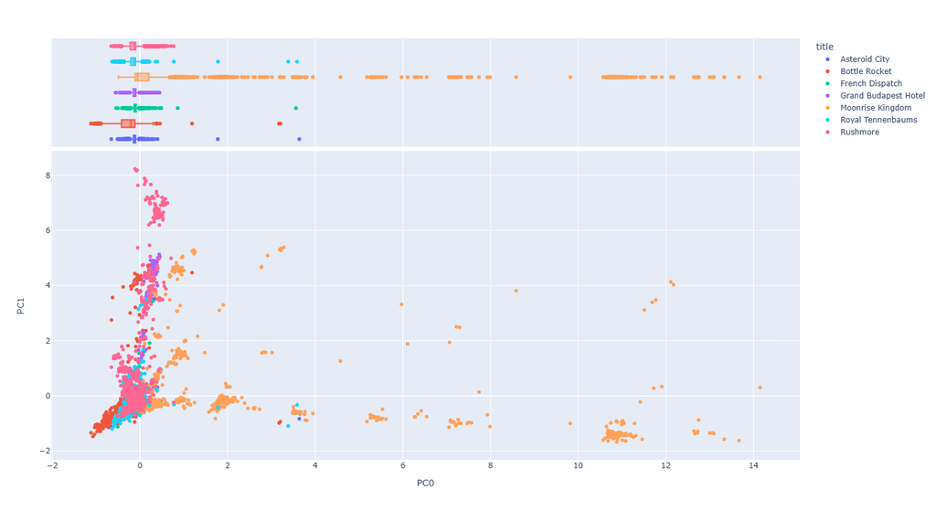

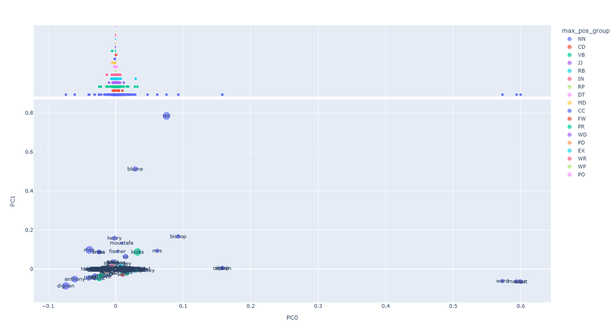

Briefly describe the nature of the polarity you see in the first component:

The first component seems to be mostly defined by Moonrise Kingdom, while the rest of the movies are associated with the second component

## PCA Visualization 2 (4)

Include a scatterplot of documents in the space created by the second two components.

Color the points based on a metadata feature associated with the documents.

Also include a scatterplot of the loadings for the same two components. (This does not need a feature mapped onto color.)

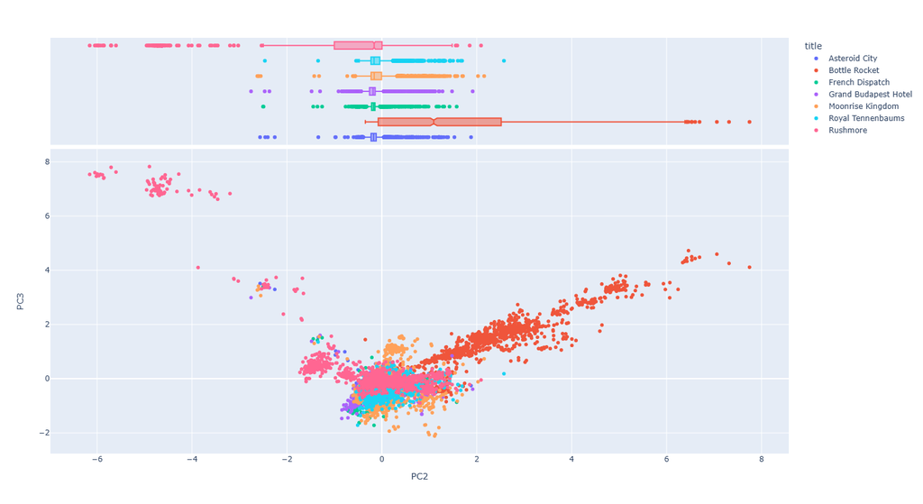

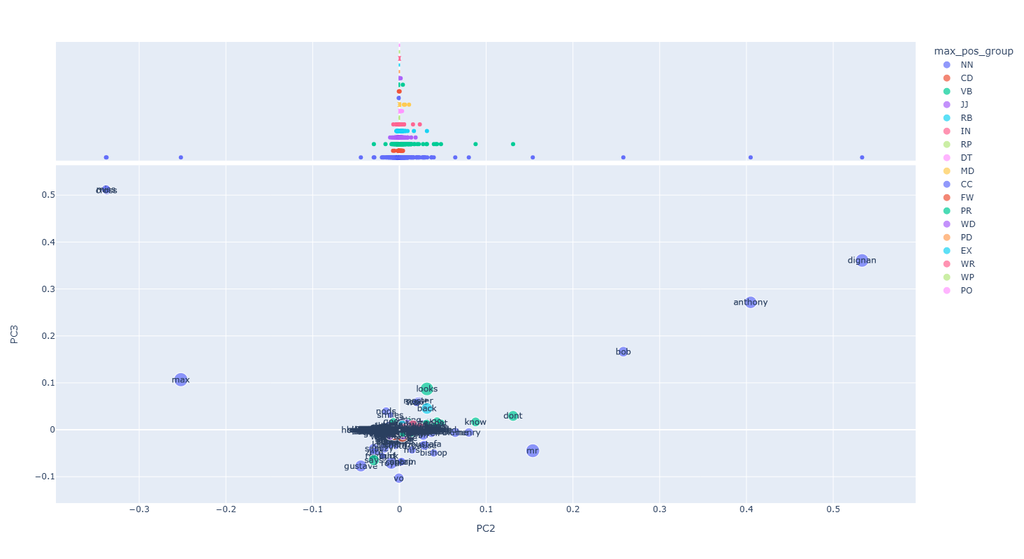

Briefly describe the nature of the polarity you see in the second component:

The second component is mostly Bottle Rocket and Rushmore. This makes sense as they are both early films.

# Models

## LDA TOPIC (4)

- UVA Box URL: https://virginia.box.com/s/m6thvsb2xritk7jz3xhayjn24ptidulf
- UVA Box URL of count matrix used to create: https://virginia.box.com/s/m6thvsb2xritk7jz3xhayjn24ptidulf
- GitHub URL for notebook used to create: https://github.com/sliplr19/Text_Analysis_Final_Project_2025
- Delimitter:,
- Libary used to compute: sklearn
- A description of any filtering, e.g. POS (Nouns and Verbs only): NNS
- Number of components: 9
- Any other parameters used:
- Top 5 words and best-guess labels for topic five topics by mean document weight:
  - T00: Personal nouns: eyes smiles end telephone pocket
  - T01: Playhouse: door minute street manager play
  - T02: Summer camp: day girls troop rest record
  - T03: Newspaper: face ground year group desk
  - T04: Writer: way years box water author

## LDA THETA (4)

- UVA Box URL: https://virginia.box.com/s/m6thvsb2xritk7jz3xhayjn24ptidulf
- GitHub URL for notebook used to create: https://github.com/sliplr19/Text_Analysis_Final_Project_2025
- Delimitter:,

## LDA PHI (4)

- UVA Box URL: https://virginia.box.com/s/m6thvsb2xritk7jz3xhayjn24ptidulf
- GitHub URL for notebook used to create: https://github.com/sliplr19/Text_Analysis_Final_Project_2025
- Delimitter:,

## LDA + PCA Visualization (4)

Apply PCA to the PHI table and plot the topics in the space opened by the first two components.

Size the points based on the mean document weight of each topic (using the THETA table).

Color the points basd on a metadata feature from the LIB table.

Provide a brief interpretation of what you see.

[figure not shown]

In word choice, Moonrise kingdom was an outlier, but, in terms of themes, Asteroid City is an outlier. If you've seen Asteroid Citym, it has a very different structure than other Wes Anderson movies, and I wonder if this contributes. It is the strongest representative of the first two themes.

## Sentiment VOCAB_SENT (4)

Sentiment values associated with a subset of the VOCAB from a curated sentiment lexicon.

- UVA Box URL: https://virginia.box.com/s/m6thvsb2xritk7jz3xhayjn24ptidulf
- UVA Box URL for source lexicon: https://virginia.box.com/s/m6thvsb2xritk7jz3xhayjn24ptidulf
- GitHub URL for notebook used to create: https://github.com/sliplr19/Text_Analysis_Final_Project_2025
- Delimitter:

## Sentiment BOW_SENT (4)

Sentiment values from VOCAB_SENT mapped onto BOW.

- UVA Box URL: https://virginia.box.com/s/m6thvsb2xritk7jz3xhayjn24ptidulf
- GitHub URL for notebook used to create: https://github.com/sliplr19/Text_Analysis_Final_Project_2025
- Delimitter:

## Sentiment DOC_SENT (4)

Computed sentiment per bag computed from BOW_SENT.

- UVA Box URL: https://virginia.box.com/s/m6thvsb2xritk7jz3xhayjn24ptidulf
- GitHub URL for notebook used to create: https://github.com/sliplr19/Text_Analysis_Final_Project_2025
- Delimitter: ,
- Document bag expressed in terms of OHCO levels: SENT

## Sentiment Plot (4)

Plot sentiment over some metric space, such as time.

If you don't have a metric metadata features, plot sentiment over a feature of your choice.

You may use a bar chart or a line graph.

[figure not shown]

## VOCAB_W2V (4)

A table of word2vec features associated with terms in the VOCAB table.

- UVA Box URL: https://virginia.box.com/s/m6thvsb2xritk7jz3xhayjn24ptidulf
- GitHub URL for notebook used to create: https://github.com/sliplr19/Text_Analysis_Final_Project_2025
- Delimitter: ,
- Document bag expressed in terms of OHCO levels: SENT
- Number of features generated: 330
- The library used to generate the embeddings: gensim

## Word2vec tSNE Plot (4)

Plot word embedding featues in two-dimensions using t-SNE.

Describe a cluster in the plot that captures your attention.

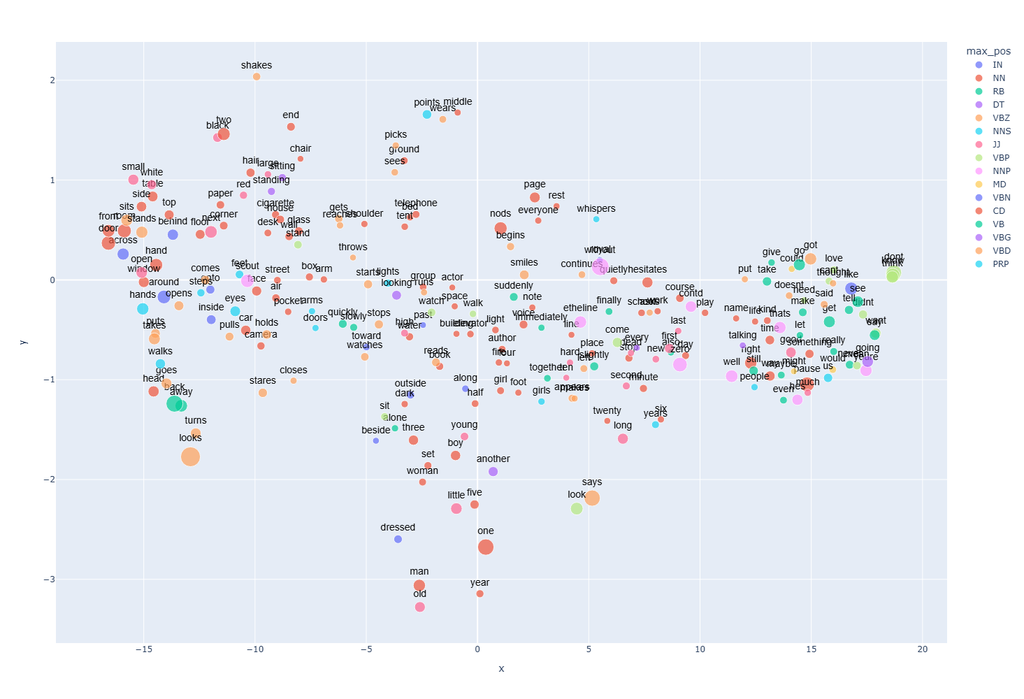

It's actually interesting that generally, there are no tight clusters; however there is some slight clustering on the right side of the plot. These are mostly simple verbs like put, take, and give. Even so, there are some words that do not fit the simple verb trend like people, he's and name.

# Riffs

Provde at least three visualizations that combine the preceding model data in interesting ways.

These should provide insight into how features in the LIB table are related.

The nature of this relationship is left open to you -- it may be correlation, or mutual information, or something less well defined.

In doing so, consider the following visualization types:

- Hierarchical cluster diagrams
- Heatmaps
- Scatter plots
- KDE plots
- Dispersion plots
- t-SNE plots
- etc.

## Riff 1 (5)

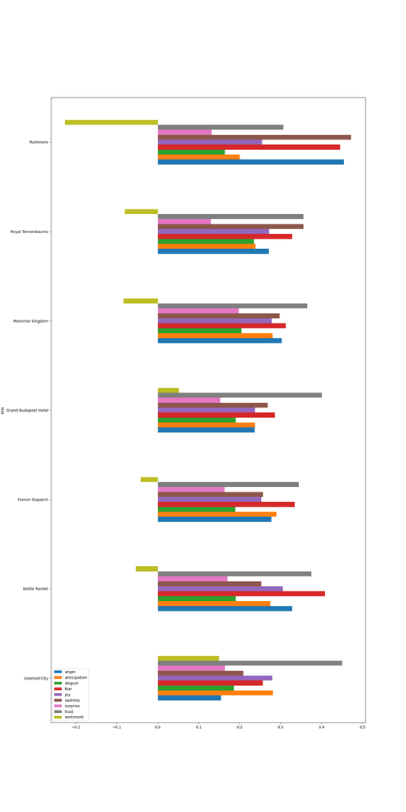

Trust is common across movies. Fear is common to the early movies. Negative sentiment is also common to the early movies. Rushmore has high levels of sadness, fear, and anger and is the most negative movie. Asteroid City is the most positive and has high levels of joy, trust, and anticipation.

## Riff 2 (5)

Late movies are the longest and have the fewest scenes. Early movies have a medium number of scenes and are the shortest. Middle movies have the greatest number of scenes and medium length. Thus, late movies have the longest scenes, while early and middle movies have shorter scenes.

```python
import pandas as pd

output_dir = "C:/Users/ddj6tu/Documents/GitHub\DS5001/Final_Project_ddj6tu/output"
data_prefix = "ANDERSON"

LIB = pd.read_csv(f"{output_dir}/{data_prefix}-LIB.csv")

ERAS = LIB.groupby('era')[['movie_len', 'n_scenes']].mean()
ERAS.style.background_gradient()
```

| era | movie_len | n_scenes |
| --- | --- | --- |
| early | 21979.333333 | 144.666667 |
| late | 29246.000000 | 122.000000 |
| middle | 26031.000000 | 157.500000 |

# Riff 3 (5)

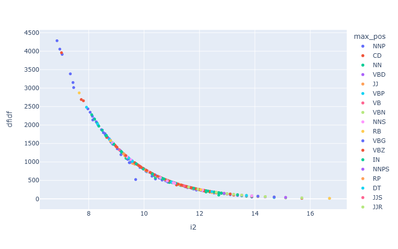

The graph shows that the more popular words (the peak at the left) tell us less about the scripts the less popular words (the minima on the right).

# Interpretation (4)

Describe something interesting about your corpus that you discovered during the process of completing this assignment.

At a minumum, use 250 words, but you may use more. You may also add images if you'd like.

The purpose of the project was to analyze differences in a selection of seven Wes Anderson scripts. As a fan who has seen all of the movies many times, I had hypothesized that there would be major differences among the films. While some differences did occur, PCA approaches showed close clustering on the first and second components. Thus, my perceived drastic differences may not be as reflected in the text as I had originally thought; however, the differences found were important.

The first difference occurred before any analysis was even done. Just in deciphering the regex codes for scene breaks revealed differences across era. The earlier scripts had very homogenous scene breaks, using mostly INT. and EXT. On the other hand, as time progressed, scripts had increasingly complex scene transitions. Thus, simply by structure of script, we see evolution of writing.

From the DFIDF, we see the most prominent characters. Max, from Rushmore, has the highest DIDF, making him the most prominently featured character. However, I would argue that Bottle Rocket is the most character-driven movie because Dignan and Anthony are in the top 5 and Bob is in the 15 (these are the three main characters of Bottle Rocket).

Sentiment analysis revealed some similarities between groups though their were some obvious outliers. Trust is common across movies, but fear and negative sentiment are also common to the early movies. The most negative movie is Rushmore with high levels of sadness, fear, and anger, and the most positive movie is Asteroid City with high levels of joy, trust, and anticipation.

Since I was interested in differences in era, I looked at mean differences in script length and number of scenes. Interestingly, while middle movies have the most scenes, late movies are the longest and have the fewest scenes. This indicates that scenes are longer in the late movies. Early movies have a medium number of scenes, but are the shortest; and middle movies have the greatest number of scenes, but medium length. Again, this indicates that the early and middle movies have shorter scenes.

In conclusion, although PCA showed many similarities, there were some differences that arose from further analysis. There are differences across era in terms of scene and movie structure, and the role of characters within the movie (i.e., in Bottle Rocket and Rushmore).